# Report

2024-04-29

## Introduction

We were interested in the relevance of OpenAI. We analysed in which sections this topic came up the most, which words were most prevalent and what the overall sentiment was.

## Collecting the Data

We created an account to access the data from the API, retrieved the data with a GET request and parsed it to extract the relevant information. We ended up with a tibble of 2390 articles, because it failed to fetch data for page 240 and onward. These were sorted by relevancy beforehand.

## Analysis

### Plot

We created a plot to show the amount of articles that were published in each section using a bar plot to showcase the distribution. The most popular sections were “Technology”, “Sport”, “Opinion”.

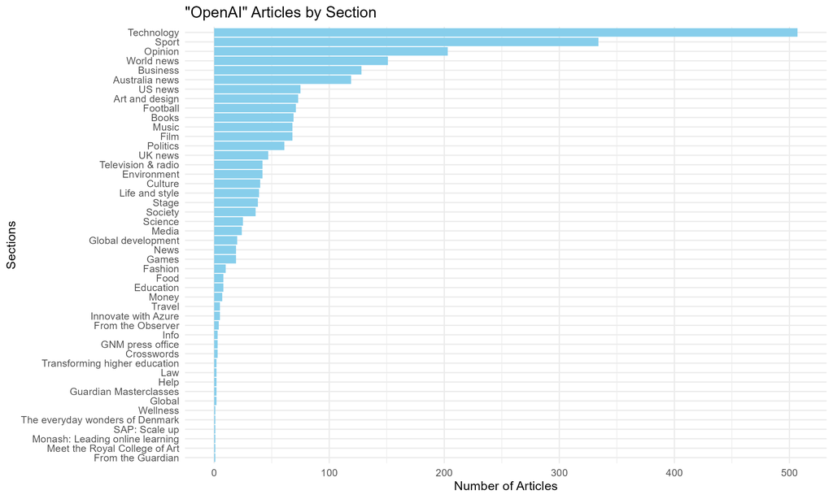

### Word cloud

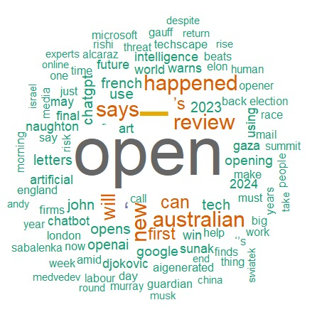

### Sentiment analysis

Finally, we defined positive (“win”, “intelligence”, “best”, …) and negative (“threat”, “risk”, “abuse”, …) words with the “bing lexicon” to rate the overall tendency in the texts each mention counting as a negative/positive point. The results showed that the overall sentiment was negative with the negative outweighing the positive words by 303.

## Conclusion

Our findings show that the most popular “OpenAI” articles are featured in various sections the most prevalent being “Technology”, “Sport” and “Opinion”. The most common words in these were positive as well as negative. However, the sentiment analysis showed that the articles had a tendency to be formulated with negative key words.